# Data Analysis Sample: Regression

Yeuk Yu Lee

# I. Introduction

Bike sharing system is believed to be useful in identifying changes in mobility in city. Some early findings have shown that weather factors, such as temperature and humidity, seemed to determine how likely a user would rent bikes, but the affect of wind speed is less obvious, given that a strong wind can either be a hindrance or help in bike rides. This report aims to uncover how wind could be influential in number of bike rental: in particular, this report will explore the hypothesis that a lower wind speed corresponds to more bike users in a given hour.

# II. Explanatory Data Analysis (EDA)

The bike usage data used in this study is a set of hourly data drawn from Washington D.C./ Arlington, VA/MD area. In this dataset, there are in total 164 hourly records, collected over seven randomly chosen days from the same month in 2011 or 2012. The variables included in the dataset are wind speed, which is wind speed in km/hour, and count, which is the total number of rental bikes being used that hour.

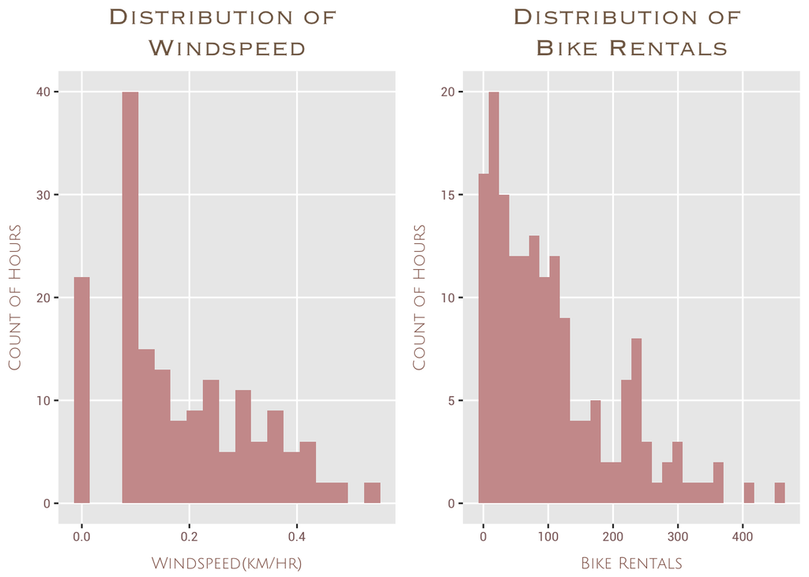